# 參數估計

## 什麼是參數估計？為什麼要參數估計？

George E. P. Box:

**All models are wrong, but some are useful**

- 我們會使用機率分佈來描述資料的變化
- 我們會留下一些不確定的參數來讓模型更符合資料

### 範例：德國坦克問題

- \(X\)代表我們抓到的坦克車之中，零件編號的分佈
- 我們**假設**\(X\)是均勻離散分佈，而我們不知道最大值\(N\)
- 我們希望知道最大值，才能推估坦克的總數

## 什麼是參數估計？為什麼要參數估計？

- 假設\(X \sim \mathcal{F}(\theta)\)，\(\mathcal{F}\)是一個有參數的分佈、\(\theta\)是參數
- \(x_1, x_2, ..., x_n\)是從\(X\)中取得的樣本
- 任何統計上估計\(\theta\)的方法，都是\(x_1, x_2, ..., x_n\)的函數：所以**估計方法都是隨機變數**
  - 記做\(\hat{\theta}\)
- 基於假設，我們可以利用\(\theta\)對我們感興趣的資訊做推測

### 範例：德國坦克問題

- 我們已經觀測到五個樣本：\(\{2, 3, 7, 16, 22\}\)。請問我們要如何估計\(N\)？
- 我們可以用最大的樣本，\(22\)，來估計\(N\)
  - 這個策略可以視為用樣本中的最大值來做估計。而樣本中的最大值是一個**隨機變數**

## 動差估計法

- \(X\)的\(n\)次動差\(E(X^n)\)可以透過樣本來簡單估計：
  - \(E(X^n) = \frac{1}{n} x_i^n\)
- 舉例來說，在上述的德國坦克問題範例中，已經觀測到五個樣本：\(\{2, 3, 7, 16, 22\}\)。我們可以估計\(X\)的1、2與3次動差分別為：
  - \(E(X) \approx \bar{x} = \frac{1}{n}\sum_{i=1}^n x_i = 10\)
  - \(E(X^2) \approx \bar{x^2} = \frac{1}{n}\sum_{i=1}^n x_i^2 = 160.4\)
  - \(E(X^3) \approx \bar{x^3} = \frac{1}{n}\sum_{i=1}^n x_i^3 = 3024.4\)

## 動差估計法

- 如果\(X\)是離散均勻分佈(Discrete Uniform Distribution)，且介於\(1\)與\(N\)之間，則機率論告訴我們：
  - \(E(X) = \frac{N+1}{2}\)
  - \(E(X^2) = \frac{(N+1)(2N+1)}{6}\)
  - \(E(X^3) = \frac{N(N+1)^2}{4}\)
- 我們可以把樣本估計的代入上面的式子中解N
  - \(\bar{x} = \frac{\hat{N}_1 + 1}{2} \Rightarrow \hat{N}_1 = 19\)
  - \(\bar{x^2} = \frac{(\hat{N}_2 + 1)(2 \hat{N}_2)+ 1}{6} \Rightarrow \hat{N}_2 = 21.1877229\)
  - \(\bar{x^3} = \frac{\hat{N}_3(\hat{N}_3 + 1)^2}{4} \Rightarrow \hat{N}_3 = 22.2944116\)

## 動差估計法的缺點

- 解出來的答案不一定在參數的合理範圍之中
  - \(N \geq 22\)，所以\(\hat{N}_1, \hat{N}_2 < 22\) 都是不合理的估計
  - \(N \in \mathbb{N}\) 但是會解出非正整數解

## 第二個例子

- 在播放1000次廣告之中，獲得了34次點擊
- 如果點擊的次數是二項式分佈(Binomial Distribution)，\(n = 1000\)、\(p\)要怎麼估計呢？

### 二項式分佈(Binomial Distribution)的動差估計法

- \(E(X) = np \Rightarrow \hat{p}_1 = 0.034\)
- \(E(X^2) = np(1 - p + np) \Rightarrow \hat{p}_2 = 0.0335183\)
- \(E(X^3) = np(1 - 3p + 3np + 2p^2 - 3Np^2 + N^2 p^2) \Rightarrow \hat{p}_3 = 0.0330702\)

## 第三個例子：多參數

- 假設\(X\)是二項式分佈(Binomial Distribution)，但是我們不知道\(n\)與\(p\)的值
- 我們觀測到5個樣本：\(8, 7, 6, 7, 9\)

### 用一階和二階動差估計\(n\)與\(p\)

\[\begin{eqnarray} & & \left\{\begin{array}{c} \bar{x} = np \\ \bar{x^2} = np(1 - p + np) \end{array}\right. \\ & \Leftrightarrow & \left\{\begin{array}{c} n = \frac{\bar{x}^2}{\bar{x} - \frac{1}{n}\sum_i(x_i - \bar{x})^2} \\ p = \frac{\bar{x}}{n} \end{array}\right. \\ & \Leftrightarrow & \left\{\begin{array}{c} n = 8.6100629 \\ p = 0.8594595 \end{array}\right. \end{eqnarray}\]

## 最大概似估計(Maximal Likelihood Estimation)

- 什麼是「概似」
- 最大概似原理

## 概似(Likelihood)

- 如果\(x_1, x_2, ..., x_n\) 都是獨立的從\(X \sim \mathcal{F}\)中抽取出來的樣本，則他們的分佈會是：

\[\prod_{i=1}^n f_X(x_1)\]

- 為什麼？
  - \(X\) 與 \(Y\) 獨立 \(\Leftrightarrow P(X \leq a \cup Y \leq b) = P(X \leq a) P(Y \leq b) \Leftrightarrow f_{X,Y}(a,b) = f_X(a) f_Y(b)\)

## 最大概似原理(Maximal Likelihood Principle)

- \(\hat{\theta}_{MLE}\) 一定會落在原本\(\theta\)的空間\(\Theta\)中

## 為什麼最大概似原理有用？

### 先來個實際問題演練

- 我有兩個銅板`A`與`B`。`A`正面的機率是0.8，`B`正面的機率是0.2
- 我挑一個銅板來丟三次，你不知道我拿的是哪一個銅板
- 三次的結果都是正面，請問你會猜我拿的是`A`還是`B`？

## 把上述的問題「數學」化

- `A`丟出三次正面的機率是\(0.8^3 = 0.512\)，先稱為\(p_A\)
- `B`丟出三次正面的機率是\(0.2^3 = 0.008\)，先稱為\(p_B\)
- 因為\(p_A > p_B\)，所以我會猜`A`

**這就是最大概似原理**

## 用最大概似估計的語言再看一次

- 丟銅板三次，正面的次數\(X\)是二項次分佈，\(n = 3, p \in \{0.2, 0.8\}\)。這個例子中，\(\theta = p\)，\(\Theta = \{0.2, 0.8\}\)
- 我們觀測到\(x = 3\)，所以
  - \(\mathcal{L}(p) = p^3\)
- 因為\(\mathcal{L}(0.2) = 0.008\)、\(\mathcal{L}(0.8) = 0.512\)，所以\(\arg \max_p \mathcal{L}(p) = 0.8\)
- 因此\(\hat{p}_{MLE} = 0.8\)
- 如果把\(\Theta\)放到\([0,1]\)上，則\(\arg \max_p \mathcal{L} = 1\)
- 所以使用最大概似估計，我們會猜`A`

## 範例：常態分佈的參數

- 如果\(x_1, x_2, ..., x_n\)是獨立的常態分佈樣本，且參數\(\mu\)是未知的，但是我們知道\(\sigma^2\)
  - \(\theta = \mu, \mu \in \mathbb{R}\)
- \(\mathcal{L}(\mu) = \prod_{i=1}^n \frac{1}{\sqrt{2 \pi} 2}e^{\frac{-(x_i - \mu)^2}{8}} \propto e^{- \frac{\sum_{i=1}^n (x_i - \mu)^2}{8}} \equiv - \sum_{i=1}^n (x_i - \mu)^2\)
  - \(\hat{\mu}_{MLE} = \arg \max_{\mu} \mathcal{L} = \bar{x}\)
- 我們用**最大概似估計**重新推導了最小平方法、平均數

## 範例：常態分佈的參數

- 如果\(x_1, x_2, ..., x_n\)是獨立的常態分佈樣本，且參數\(\mu\)與\(\sigma^2\)都是未知的
  - \(\theta = \{\mu, \sigma\}, \mu \in \mathbb{R}, \sigma > 0\)
- \(\mathcal{L}(\mu, \sigma) = \prod_{i=1}^n \frac{1}{\sqrt{2 \pi} \sigma}e^{\frac{-(x_i - \mu)^2}{2\sigma^2}} \propto \sigma^{-n} e^{- \frac{\sum_{i=1}^n (x_i - \mu)^2}{2\sigma^2}}\)
  - \(\hat{\mu}_{MLE} = \arg \max_\mu L(\mu, \sigma) \equiv \arg \max_\mu - \sum_{i=1}^n (x_i - \mu)^2 = \bar{x}\)
- 即使在\(\sigma\)未知的狀況下，最小平方法仍然可用
- \(\hat{\sigma}_{MLE} = \arg \max_{\sigma} \sigma^{-n} e^{\frac{-\sum_{i=1}^n(x_i - \bar{x})^2}{2\sigma^2}}\)

## 德國坦克問題的MLE

- 如果\(x_1, x_2, ..., x_n\)是獨立的離散均勻分佈的樣本，\(N\)未知
  - \(N \in \mathbb{N}, N \geq x_{(n)}\)
- \(\mathcal{L}(N) = \prod_{i=1}^n \frac{1}{N} = \frac{1}{N^n}\)
  - \(N\)越小，\(\mathcal{L}(N)\)越大，所以\(\hat{N}_{MLE} = x_{(n)}\)

## 貝氏統計與貝式估計

### 貝式定理

\[P(A | B) = \frac{P(A \cap B)}{P(B)} = \frac{ P(B | A) P(A) }{ P(B)}\]

### 貝式統計

- 參數\(\theta\)不是一個未知的固定值，而是一個隨機變數。它的PDF記做\(\pi(\theta)\)
- 我們過去介紹的各種統計分部、統計模型都是\(f(x | \theta)\)或\(P(X = x|\theta)\)
- 根據觀察到的資料，\(x\)，我們反過來對參數做推論：
  - \(f(\theta | x) = \frac{f(x | \theta) \pi(\theta)}{f(x)} \propto f(x | \theta) \pi(\theta)\)

## 範例

### 投擲硬幣的正面次數

- \(X\)代表丟擲硬幣五次，會出現的正面次數
- \(X\)是二項式分佈：\(P(X = x) = \left(\begin{array}{c}n \\ x\end{array}\right)p^x(1-p)^{n-x}\)
- 參數是\(n\)與\(p\)，\(n = 5\)而\(p\)未知
- \(x\)是我們收集的資料，是已知
- 貝式統計認為，\(p\)也是隨機變數
- 如果\(p\)是變數，而且的分佈是\(\pi(p)\)的話，根據貝式定理，我們可以得到基於觀測到的\(x\)，對\(p\)做統計推論

## 範例

### 投擲硬幣的正面次數

- \(\pi\)是給定的。有各種方法可以設計\(\pi\)，或是直接主動定一個。我們這裡定\(\theta\)是貝塔分佈，且\(\alpha = 2, \beta = 1\)
  - \(\pi(p) \propto p\)
- 我看到了四次正面：\(x = 4\)，我們可以做什麼統計推論呢？
  - 首先，計算\(f(p | x) \propto p^{x+1}(1-p)^{n-x} = p^5(1-p)\) 所以\(p | x \sim Beta(\alpha = 6, \beta = 2)\)
  - \(p | x\)的期望值是多少？\(0.75\)
  - \(p | x\)有分散？或是\(p | x\)的變異數有多大？\(0.0208333\)
  - 可以預測下一次正面的機率嗎？\(0.75\)

## 估計方法的比較

- 偏差(Bias)
- 變動(Variance)

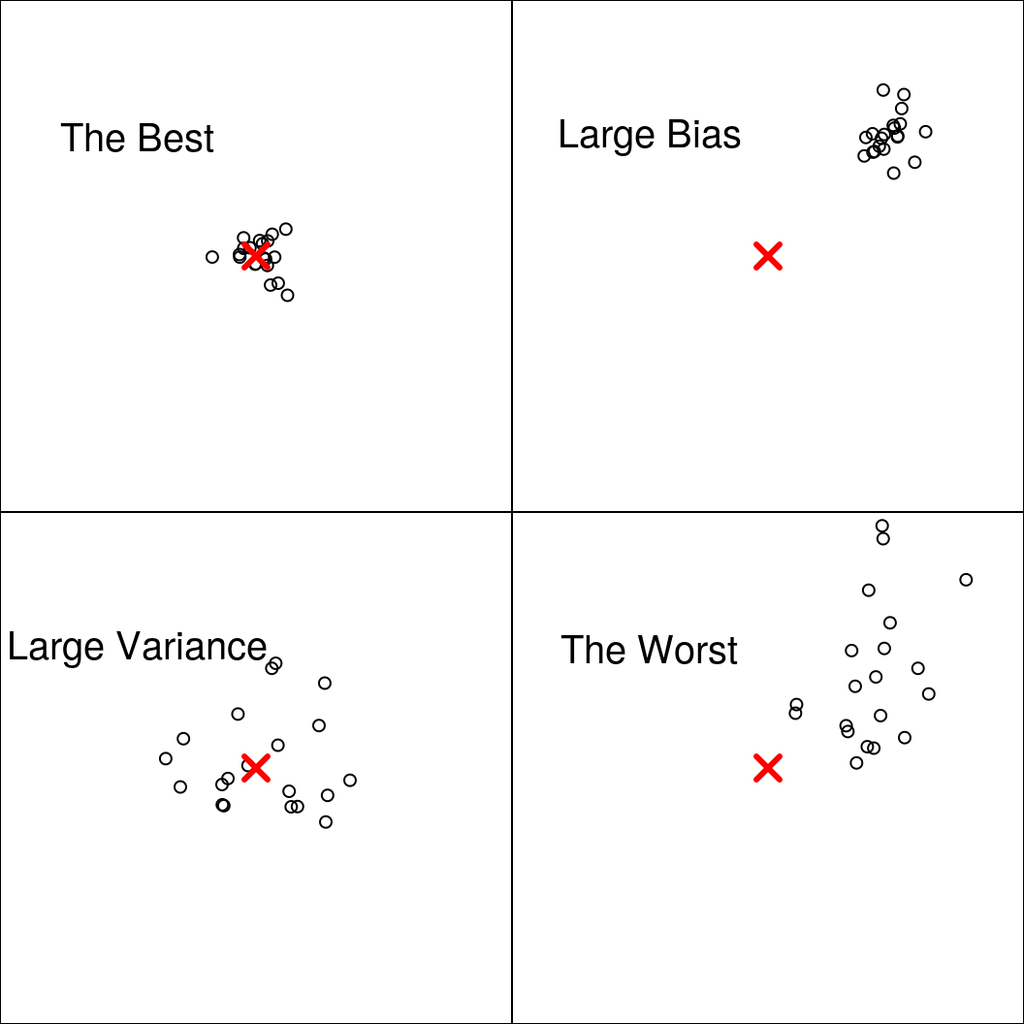

## 均方差(Mean Squared Error)

- 若\(\hat{\theta}\)是\(\theta\)的估計量，則均方差(Mean Squared Error)的定義為：

\[E\left((\hat{\theta} - \theta)^2\right)\]

- \(x_1, x_2, ..., x_n \sim \mathcal{F}(\theta)\)
- \(\hat{\theta}(x_1, x_2, x_3, ..., x_n)\)也是隨機變數
- 因為\(\hat{\theta}\)是\(x_1, x_2, x_3, ..., x_n\)的函數，所以它的分佈會與\(\theta\)有關
- 因為\(\hat{\theta}\)的分佈與\(\theta\)有關，所以\(E(\hat{\theta})\)、\(E(\hat{\theta}^2)\)等都是\(\theta\)的函數。
- 所以\(E\left((\hat{\theta} - \theta)^2\right)\)也是\(\theta\)的函數。

## 為什麼是均方差(Mean Squared Error)？

- 偏差(Bias)：\(E(\hat{\theta}) - \theta\)
- 變動(Variance)：\(Var(\hat{\theta})\)

\[\begin{eqnarray} E\left((\hat{\theta} - \theta)^2\right) & = & E\left((\hat{\theta} - E(\hat{\theta}) + E(\hat{\theta}) - \theta)^2\right) \\ & = & Var(\hat{\theta}) + (\hat{\theta} - \theta)^2 \\ & = & \text{Variance} + \text{Bias}^2 \end{eqnarray}\]

## 範例：常態分佈

- 若\(x_1, x_2, ..., x_n\)是獨立且常態分佈\(\mathcal{N}(\mu, \sigma^2)\)的樣本。
- 平均數\(\bar{x} = \frac{1}{n} x_i\)是\(\mu\)的估計

\[E(\bar{x}) = E\left(\frac{1}{n}\sum_{i=1}^n x_i\right) = \frac{1}{n}\sum_{i=1}^n E(x_i) = \mu\]

- 因為\(E(\bar{x}) = \mu\)，所以\(\bar{x}\)被稱為\(\mu\)的**無偏**估計
- 平均數的均方差為：

\[E((\bar{x} - \mu)^2) = Var(\bar{x}) = \frac{\sigma^2}{n}\]

- \(\tiny{Var(\frac{1}{n}\sum_{i=1}^n x_i) = \frac{1}{n^2}\left(\sum_{i=1}^n Var(x_i)\right) = \frac{\sigma^2}{n}}\)

## 範例：常態分佈

- 已知\(E\left((x_i - \bar{x})^2\right) = (n-1)\sigma^2\)，所以常用的樣本標準差\(S^2 = \frac{1}{n-1} \sum_{i=1}^n (x_i - \bar{x})^2\)是\(\sigma^2\)的不偏估計
- 已知\(E\left((S^2 - \sigma^2)^2\right) = \frac{2\sigma^4}{n - 1}\)
- 所以\(S^2\)的均方差為：\(\frac{2\sigma^4}{n - 1}\)
- \(\frac{n-1}{n}S^2\)是\(\sigma^2\)的最大概似估計\(\hat{\sigma^2}_{MLE}\)，而它的均方差為：

\[E\left((\frac{n-1}{n}S^2 - \sigma^2)^2\right) = \frac{(n-1)^2}{n^2} \frac{2\sigma^4}{n - 1} + \frac{1}{n^2}\sigma^4 = \frac{2n-1}{n^2}\sigma^4\]

- 如果\(n = 100\)，\(\frac{199}{10000} \approx 0.0199 < 0.0202 \approx \frac{2}{99}\)，也就是\(\hat{\sigma^2}_{MLE}\)得均方差比較好
- 但是\(S^2\)是無偏估計，\(\hat{\sigma^2}_{MLE}\)不是。這是偏差與變異的交換的範例。

## 最佳無偏估計

- 有時候，人們更喜歡無偏估計。例如常態分佈的\(\sigma^2\)的估計中，樣本標準差\(S^2\)比最大概似估計更普遍。
  - 即使在剛剛我們才提到，最大概似估計的均方差更好
- 在所有的無偏估計中，變異數最小的就是最好的估計，稱之為**最佳無偏估計**
- 統計學家有推導出一些尋找最佳無偏估計的方法，例如Cramér–Rao不等式。
- 但是要證明或反證出一個實際有用的估計是不是最佳無偏估計，仍然是困難的問題

## Stein’s Paradox (1955)

- 想像下列情境：
  - 老闆根據過去產品的表現(但是只有一筆)，要我們估計未來的產品的售量
  - 老闆根據過去的進貨成本(但是只有一筆)，要我們估計未來的進貨的成本
  - 我們個人對某檔基金的表現有興趣(但是只有一筆)，收集了基金的歷史數據
- Stein’s Paradox 說，如果你已經有了對這三個問題的各自的估計，那你可以把他們混在一起，以**均方差**的觀點來看，**平均**來說混在一起的估計會更好！

## Stein’s Paradox (1955)

- \(X_1 \sim \mathcal{N}(\mu_1, 1)\)，有一個樣本\(x_1\)
  - 如果用\(X_1\)估計\(\mu_1\)，均方差會是1
- \(X_2 \sim \mathcal{N}(\mu_2, 1)\)，有一個樣本\(x_2\)
  - 如果用\(X_2\)估計\(\mu_2\)，均方差會是1
- \(X_3 \sim \mathcal{N}(\mu_3, 1)\)，有一個樣本\(x_3\)
  - 如果用\(X_3\)估計\(\mu_3\)，均方差會是1
- 所以同時考慮用\((x_1, x_2, x_3)\)估計\((\mu_1, \mu_2, \mu_3)\)的均方差為3
- Stein提出一個新的估計：\(\hat{\mu}^{JS} = \left(1 - \frac{1}{X_1^2 + X_2^2 + X_3^2}\right)X_i\)
  - 它技巧的「收縮」了\(x_1, x_2, x_3\)
- 可以證明\(\hat{\mu}^{JS}\)的均方差為\(3 - E(\frac{1}{X_1^2 + X_2^2 + X_3^2}) < 3\)

## Stein’s Paradox 的啟示

- 請小心任何**平均指標**：
  - 平均比較好的，對於個別來看不一定會比較好！
- **收縮**，或是後續被稱作**Regularization**的技術，在近代機器學習應用中被廣泛使用
  - 統計學家很早就知道「收縮」對於**整體優化**具有改善的能力
  - 也許Stein’s Paradox稍微說服你相信**收縮**對於改善複雜的估計有神奇的效果

## 大樣本下的參數估計救星：最大概似估計

- 在大多數的狀況下，我們不知道**最佳估計**是什麼
- 但是在大部分的狀況下，統計學家證明**最大概似估計**在資料很大的時候，和**最佳估計**差不多好

## 大樣本下我們要關心的估計問題

- 當資料越來越多的時候，估計會不會越來越準？(Consistency)

### 範例

- \(x_1, x_2, ..., x_n\)是彼此獨立且來自相同的常態分佈\(\mathcal{N}(\mu, \sigma^2)\)的樣本
- 不論有多少筆資料，我們只用第一筆來估計\(x_1\)
- 這種估計方法不會因為資料變多而越來越準確

## 大樣本下我們要關心的估計問題

- 當資料越來越多的時候，估計的誤差會不會和理論上的最佳誤差差不多好？(Efficiency)

### 範例

- 統計學家證明了，在大部分的狀況下，**最大概似估計**在資料夠大的狀況下的是無偏的
- 統計學家也證明了，**最大概似估計**的變異數和**理論上的最佳下界**會隨著資料量變大而縮小

## 什麼是大部分的狀況？

- 基本上應用問題會遇到的狀況都算是這裡的大部分的狀況，**除了**：
  - 隨機變數的有效範圍和參數有關的狀況，例如：德國坦克問題